# Homework 2

ZhangGe LiAnran LiHongxu FanZiyi HeHouting

2017年4月4日

## R Markdown

1. The scatterplot is placed at following picture.

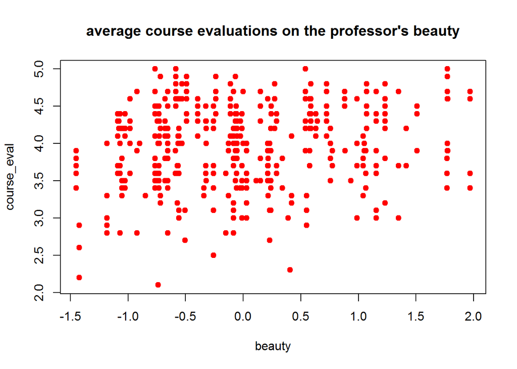

```r
A<- read.csv("TeachingRatings.csv",header = TRUE)
attach(A)
plot(main = "average course evaluations on the professor's beauty",beauty,course_eval,pch=19,col = "red")
```

```r
test = lm(course_eval~1+beauty)
test
```

```
##
## Call:
## lm(formula = course_eval ~ 1 + beauty)
##
## Coefficients:
## (Intercept)       beauty
##       3.998        0.133
```

```r
summary(test)
```

```
##
## Call:
## lm(formula = course_eval ~ 1 + beauty)
##
## Residuals:
##      Min       1Q   Median       3Q      Max
## -1.80015 -0.36304  0.07254  0.40207  1.10373
##
## Coefficients:
##             Estimate Std. Error t value Pr(>|t|)
## (Intercept)  3.99827    0.02535 157.727  < 2e-16 ***
## beauty       0.13300    0.03218   4.133 4.25e-05 ***
## ---
## Signif. codes:  0 '***' 0.001 '**' 0.01 '*' 0.05 '.' 0.1 ' ' 1
##
## Residual standard error: 0.5455 on 461 degrees of freedom
## Multiple R-squared:  0.03574,    Adjusted R-squared:  0.03364
## F-statistic: 17.08 on 1 and 461 DF,  p-value: 4.247e-05
```

```r
pred=data.frame(beauty=2.0)
test.pred=predict(test,pred,interval="prediction",level=0.95)
test.pred
```

```
##        fit      lwr      upr
## 1 4.264275 3.183811 5.344739
```

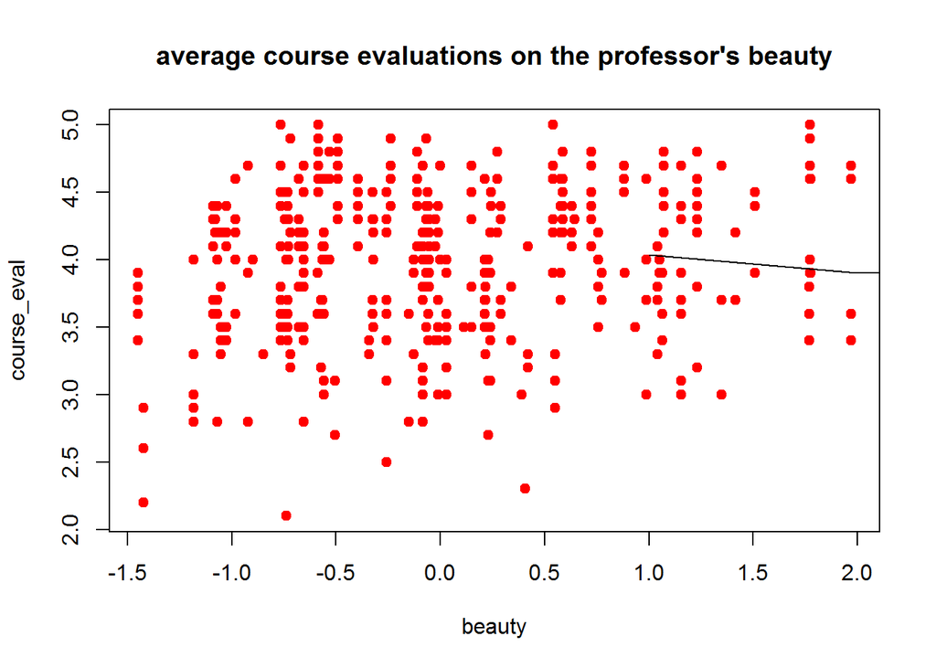

```r
nihe=predict(test)
plot(main = "average course evaluations on the professor's beauty",beauty,course_eval,pch=19,col = "red")
lines(nihe)
```

```r
mean(beauty)
```

```
## [1] 6.263499e-08
```

2. estimated intercept=3.998 estimated slope=0.133 Because of mean(beauty)=0 so, mean(course_eval)=slope*mean(beauty)+intercept =slope*0+intercept=intercept=3.998

```r
sd(beauty)
```

```
## [1] 0.7886477
```

```r
0.133*0.789+3.998
```

```
## [1] 4.102937
```

c.value(beauty) of Watson=0, course_eval of Waston=0.133*0+3.998=3.998;

value(beauty) of Stock=0+standard deviation=0+0.789=0.789, course_eval of Stock=0.133*0.789+3.998=4.103;

4. The coefficient slope = 0.133; The effect to course evaluations is small; Small infers that the δ(delta) of beauty cause a small influnence to course_eval,while big infers that δ of beauty can make course_eval changing a lot too. That means there exist a weak positive correlation between the two variables. Although the course evaluations with more beauty’s class is better, the determining factors about the course evaluations made the observtions didn’t just loaded at the regression line.

```r
var(course_eval)
```

```
## [1] 0.3078758
```

5. the variance(course_eval) = 0.308 Variance is used to measure the degree of deviation between a random variable and its mathematical expectation. The var(course_eval) is small, that means the observations is closed to the mean of course_eval, and beauty cause a limited impact to each course evalution. The regression R2 is 0.036, so that Beauty explains only 3.6% of the variance in course evaluations. Therefore, beauty can’t explain a large fraction of the variance in evaluations across courses.